# Flux Data Summary

Trevor Williams

September 4, 2019

## N2O Flux Data

This is a preliminary report on **N2O Flux Data** from the Willamette project. Many sources were referenced for the various tests employed including https://rcompanion.org/handbook/index.html.

This document will serve as a template for initial reporting of data from all fields and plots, including CO2 flux and water anlyses.

```
## [1] "C:/Users/twilli2/Documents/R/R-3.5.1/library"
```

```
##  field     chamber               date                     compound
##  1:139   Length:560         Min.   :2017-10-03 00:00:00   co2:  0
##  2:140   Class :character   1st Qu.:2018-01-31 00:00:00   n2o:560
##  3:141   Mode  :character   Median :2018-06-13 00:00:00
##  4:140                      Mean   :2018-08-04 13:27:25
##                             3rd Qu.:2019-02-20 00:00:00
##                             Max.   :2019-06-11 00:00:00
##
##     soiltemp            0                 25                 50
##  Min.   :-1.000   Min.   :-8.1600   Min.   :-16.9900   Min.   :-11.580
##  1st Qu.: 5.900   1st Qu.:-0.7200   1st Qu.: -0.4850   1st Qu.: -0.240
##  Median : 9.200   Median : 0.0700   Median :  0.2200   Median :  0.430
##  Mean   : 9.575   Mean   : 0.4273   Mean   :  0.6599   Mean   :  1.039
##  3rd Qu.:12.950   3rd Qu.: 0.8200   3rd Qu.:  1.1250   3rd Qu.:  1.300
##  Max.   :19.000   Max.   :28.5900   Max.   : 30.8700   Max.   : 46.880
##  NA's   :20       NA's   :157       NA's   :158        NA's   :155
##        75               100               C                 P
##  Min.   :-14.400   Min.   :-4.240   Min.   : -5.900   Min.   :-13.070
##  1st Qu.:  0.130   1st Qu.: 0.230   1st Qu.:  0.060   1st Qu.: -0.110
##  Median :  1.100   Median : 1.135   Median :  0.910   Median :  0.650
##  Mean   :  2.904   Mean   : 3.413   Mean   :  2.202   Mean   :  1.968
##  3rd Qu.:  2.650   3rd Qu.: 3.388   3rd Qu.:  1.935   3rd Qu.:  1.650
##  Max.   : 58.540   Max.   :68.930   Max.   :104.520   Max.   :115.430
##  NA's   :155       NA's   :158      NA's   :25        NA's   :23
```

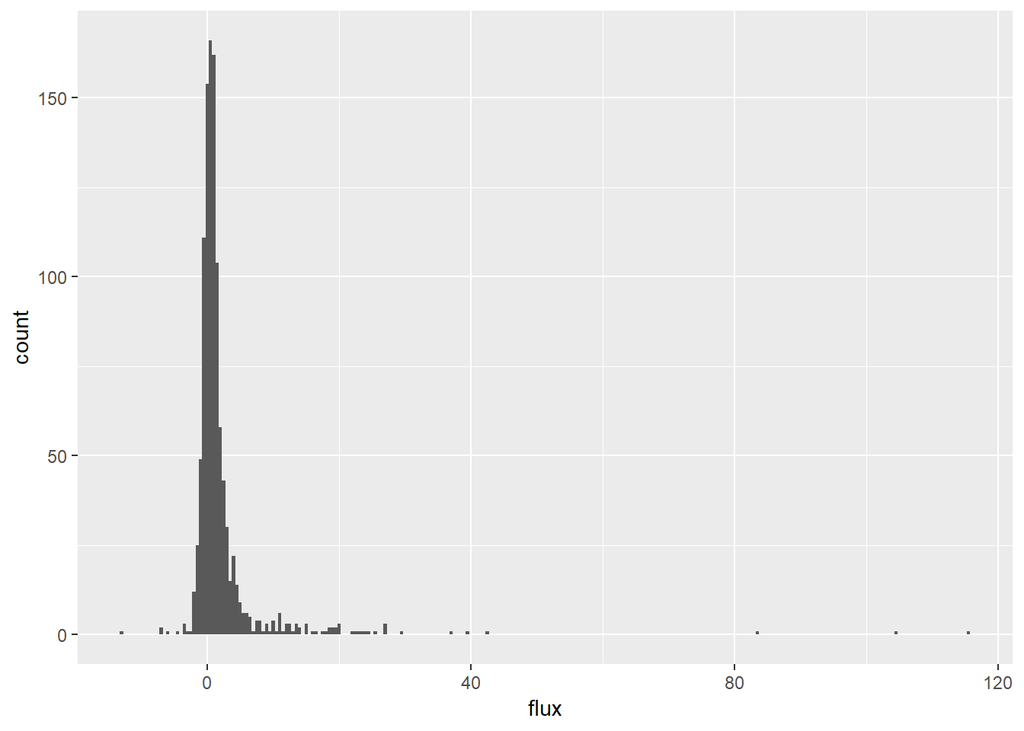

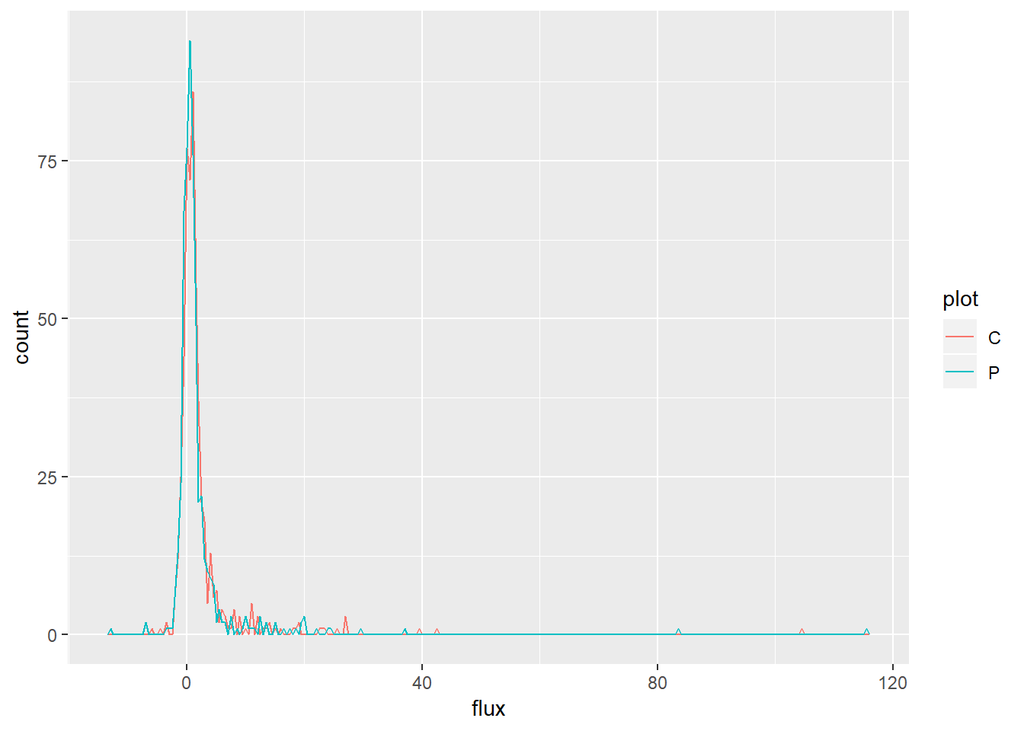

```
##
##  Shapiro-Wilk normality test
##
## data:  flux_data_n2o_cp$flux
## W = 0.34816, p-value < 2.2e-16
```

Null hypothesis for Shapiro-Wilk test, that data are from a normal distribution is rejected. First lets focus on the the Conventional VS Precicion Agriculture or Enhanced Efficiency Fertilizer

## Conv. VS P.A.

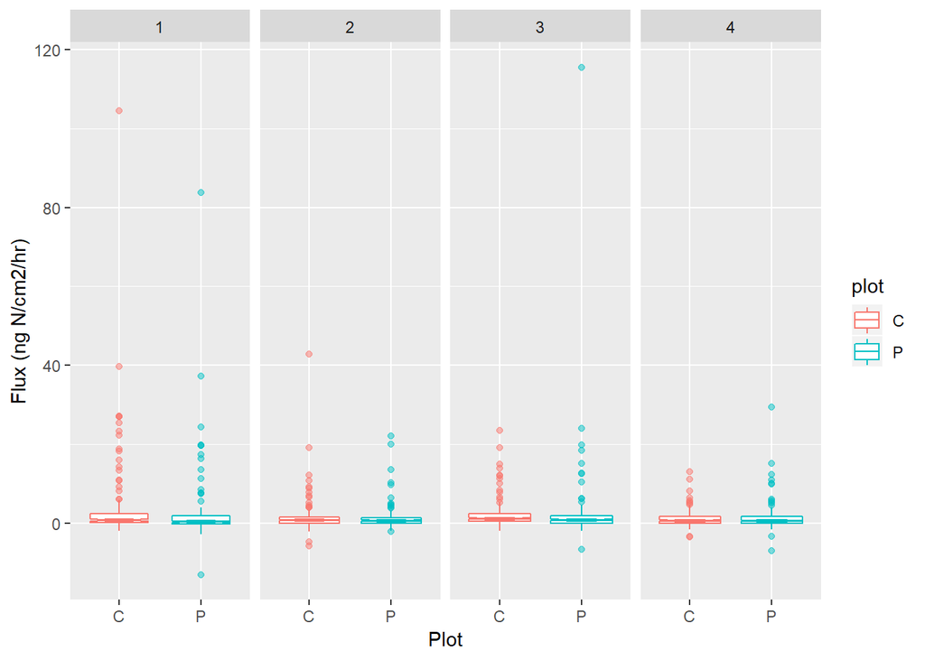

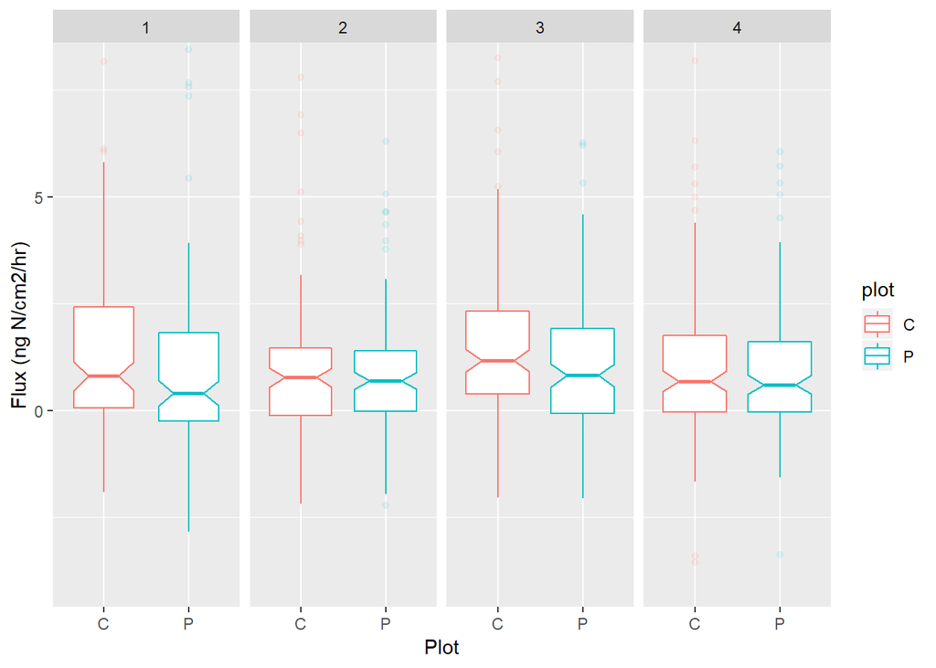

First boxplot shows full range of data with outliers.

Second boxplot shows the central tendency of the data clearly, with 50% of the data indicated by the box, the median clearly visible as a line in the middle, and the IQ range +/- 1.5 indicated by the whiskers.

#### T-tests are for normally distrubted data around the mean.

#### Welch Two Sample t-Test for unequal variance

```
##
##  Welch Two Sample t-test
##
## data:  flux by plot
## t = 0.55268, df = 1053.5, p-value = 0.5806
## alternative hypothesis: true difference in means is not equal to 0
## 95 percent confidence interval:
##  -0.5956259  1.0627142
## sample estimates:
## mean in group C mean in group P
##        2.201607        1.968063
```

### Field 1

```
##
##  Two Sample t-test
##
## data:  flux by plot
## t = 1.087, df = 246, p-value = 0.2781
## alternative hypothesis: true difference in means is not equal to 0
## 95 percent confidence interval:
##  -1.176369  4.073544
## sample estimates:
## mean in group C mean in group P
##        4.146748        2.698160
```

### Field 2

```
##
##  Two Sample t-test
##
## data:  flux by plot
## t = 0.49295, df = 262, p-value = 0.6225
## alternative hypothesis: true difference in means is not equal to 0
## 95 percent confidence interval:
##  -0.7229837  1.2058625
## sample estimates:
## mean in group C mean in group P
##        1.562652        1.321212
```

### Field 3

```
##
##  Welch Two Sample t-test
##
## data:  flux by plot
## t = -0.39915, df = 172.8, p-value = 0.6903
## alternative hypothesis: true difference in means is not equal to 0
## 95 percent confidence interval:
##  -2.200911  1.460482
## sample estimates:
## mean in group C mean in group P
##        2.150429        2.520643
```

### Field 4

```
##
##  Welch Two Sample t-test
##
## data:  flux by plot
## t = -0.65197, df = 230.65, p-value = 0.5151
## alternative hypothesis: true difference in means is not equal to 0
## 95 percent confidence interval:
##  -0.9138775  0.4594489
## sample estimates:
## mean in group C mean in group P
##        1.146286        1.373500
```

#### No significant difference between means, with 95% CI falling below means in both groups in all field

| NONPARAMETRIC TEST | PARAMETRIC ALTERNATIVE |
| --- | --- |
| 1-sample sign test | One-sample Z-test, One sample t-test |
| 1-sample Wilcoxon Signed Rank test | One sample Z-test, One sample t-test |
| Friedman test | Two-way ANOVA |
| Kruskal-Wallis test | One-way ANOVA |
| Mann-Whitney test | Independent samples t-test |
| Mood’s Median test | One-way ANOVA |
| Spearman Rank Correlation | Correlation Coefficient |

### Wilcox tests

#### Results of Wilcoxon rank sum test on all fields and each field individually

All fields

```
##
##  Wilcoxon rank sum test with continuity correction
##
## data:  flux by plot
## W = 156050, p-value = 0.01444
## alternative hypothesis: true location shift is not equal to 0
```

Significant, p-value < 0.05

Field 1

```
##
##  Wilcoxon rank sum test with continuity correction
##
## data:  flux by plot
## W = 8750.5, p-value = 0.05996
## alternative hypothesis: true location shift is not equal to 0
```

Field 2

```
##
##  Wilcoxon rank sum test with continuity correction
##
## data:  flux by plot
## W = 8895.5, p-value = 0.768
## alternative hypothesis: true location shift is not equal to 0
```

Field 3

```
##
##  Wilcoxon rank sum test with continuity correction
##
## data:  flux by plot
## W = 11288, p-value = 0.02806
## alternative hypothesis: true location shift is not equal to 0
```

Significant, p-value < 0.05

Field 4

```
##
##  Wilcoxon rank sum test with continuity correction
##
## data:  flux by plot
## W = 10041, p-value = 0.7226
## alternative hypothesis: true location shift is not equal to 0
```

### Median Tests

[output not shown]

```
## *** Package RVAideMemoire v 0.9-73 ***
```

```
##   plot   n nvalid  mean    sd    min    Q1 median    Q3    max percZero
## 1    C 559    535 2.202 6.458  -5.90  0.06   0.91 1.935 104.52    0.561
## 2    P 559    537 1.968 7.350 -13.07 -0.11   0.65 1.650 115.43    0.372
```

### Median Test for all fields

```
##
##  Mood's median test
##
## data:  flux by plot
## X-squared = 6.5821, df = 1, p-value = 0.0103
```

```
## $Unadjusted
##    C        P
## C NA 0.008654
## P NA       NA
##
## $Method
## [1] "fdr"
##
## $Adjusted
##          C        P
## C 1.000000 0.008654
## P 0.008654 1.000000
```

```
##   C   P
## "a" "b"
```

The median of the C plots is significantly higher than the median of the P plots, overall.

### Field 1

```
##
##  Mood's median test
##
## data:  flux by plot
## X-squared = 4.1293, df = 1, p-value = 0.04215
```

```
## $Unadjusted
##    C       P
## C NA 0.03118
## P NA      NA
##
## $Method
## [1] "fdr"
##
## $Adjusted
##         C       P
## C 1.00000 0.03118
## P 0.03118 1.00000
```

```
##   C   P
## "a" "b"
```

```
##   plot   n nvalid  mean     sd    min    Q1 median    Q3    max percZero
## 1    C 139    123 4.147 11.564  -1.91  0.07   0.81 2.415 104.52    1.626
## 2    P 139    125 2.698  9.321 -13.07 -0.25   0.41 1.820  83.69    0.800
```

In field 1, the median of the C plot is significantly higher than the median of the P plot

### Field 2

```
##
##  Mood's median test
##
## data:  flux by plot
## X-squared = 0.37879, df = 1, p-value = 0.5383
```

```
## $Unadjusted
##    C     P
## C NA 0.461
## P NA    NA
##
## $Method
## [1] "fdr"
##
## $Adjusted
##       C     P
## C 1.000 0.461
## P 0.461 1.000
```

```
## $Letters
##   C   P
## "a" "a"
##
## $LetterMatrix
##      a
## C TRUE
## P TRUE
```

```
##   plot   n nvalid  mean    sd   min     Q1 median    Q3   max percZero
## 1    C 140    132 1.563 4.618 -5.90 -0.115  0.775 1.468 42.72    0.758
## 2    P 140    132 1.321 3.216 -2.21 -0.018  0.695 1.403 22.01    0.000
```

No significant difference in plot medians of Field 2

### Field 3

```
##
##  Mood's median test
##
## data:  flux by plot
## X-squared = 6.3, df = 1, p-value = 0.01207
```

```
## $Unadjusted
##    C       P
## C NA 0.00867
## P NA      NA
##
## $Method
## [1] "fdr"
##
## $Adjusted
##         C       P
## C 1.00000 0.00867
## P 0.00867 1.00000
```

```
##   C   P
## "a" "b"
```

[output not shown]

Median of C is significantly higher than median of P in field 3

### Field 4

```
##
##  Mood's median test
##
## data:  flux by plot
## X-squared = 0.014286, df = 1, p-value = 0.9049
```

```
## $Unadjusted
##    C      P
## C NA 0.8114
## P NA     NA
##
## $Method
## [1] "fdr"
##
## $Adjusted
##        C      P
## C 1.0000 0.8114
## P 0.8114 1.0000
```

```
## $Letters
##   C   P
## "a" "a"
##
## $LetterMatrix
##      a
## C TRUE
## P TRUE
```

```
##   plot   n  mean    sd   min     Q1 median    Q3   max
## 1    C 140 1.146 2.156 -3.55 -0.030  0.685 1.752 13.02
## 2    P 140 1.373 3.515 -6.99 -0.028  0.605 1.605 29.45
```

No significant differences in medians of plots in Field 4

## Gradient Plots

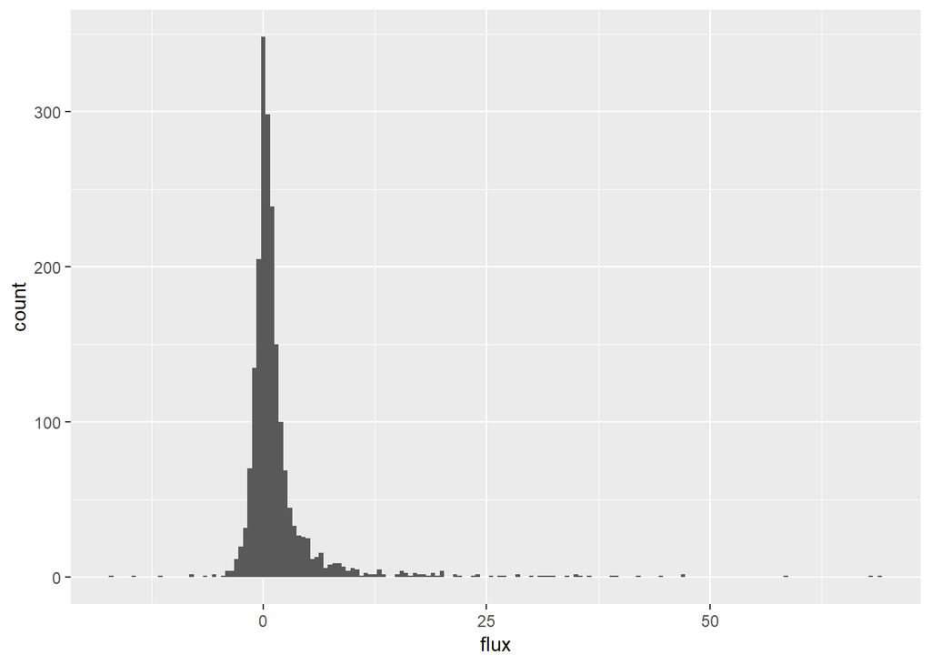

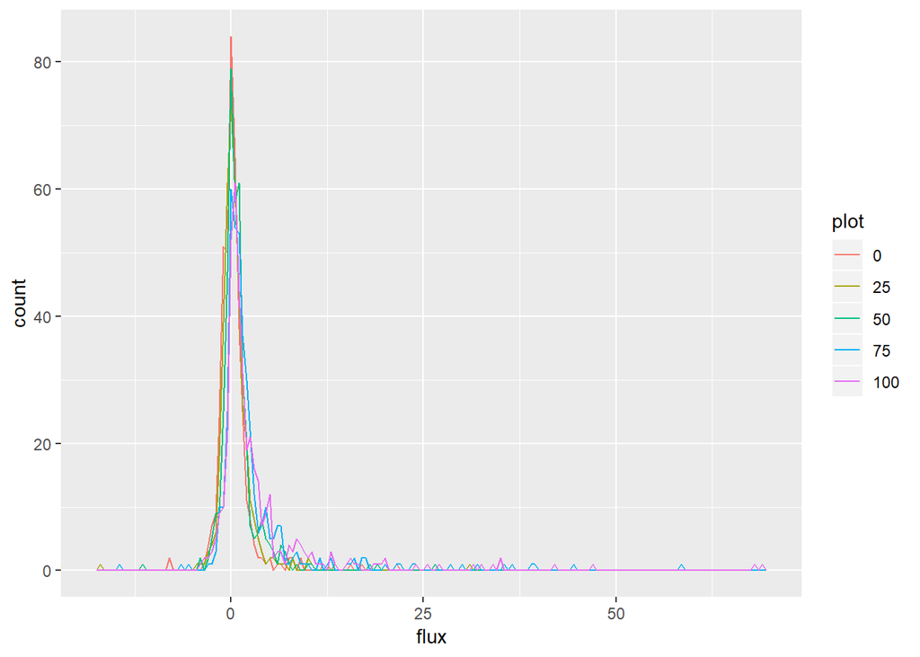

```
##
##  Shapiro-Wilk normality test
##
## data:  flux_data_n2o_g$flux
## W = 0.48322, p-value < 2.2e-16
```

#### Null hypothesis that data are from normal distribution is rejected.

```
##            n       nvalid         mean           sd          min
## 2100.0000000 2017.0000000    1.6889836    5.3465891  -16.9900000
##           Q1       median           Q3          max     percZero
##   -0.2300000    0.5200000    1.6900000   68.9300000    0.3966287
```

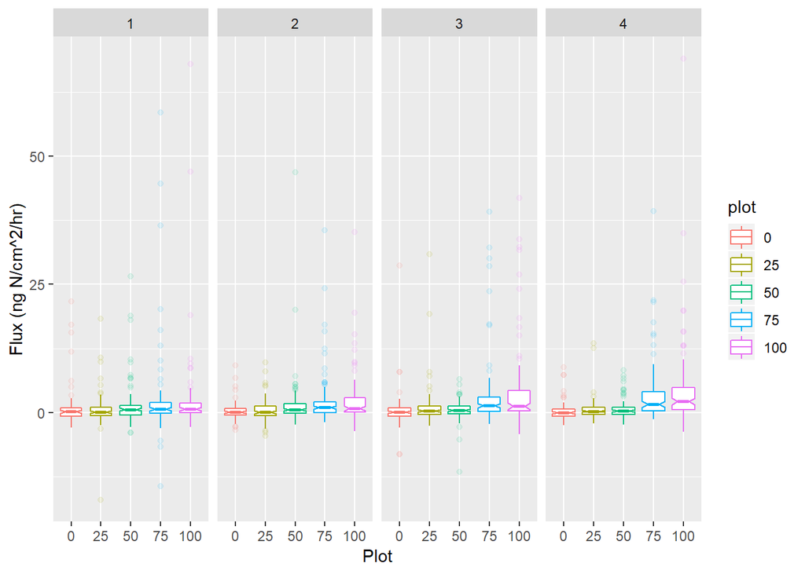

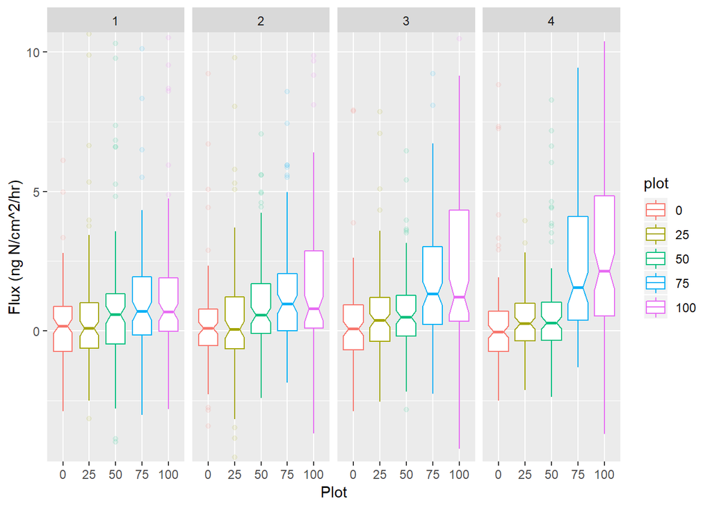

```
## # A tibble: 525 x 7
##    field plot  chamber date                compound  flux soiltemp
##    <fct> <fct> <chr>   <dttm>              <fct>    <dbl>    <dbl>
##  1 1     0     1       2017-10-03 00:00:00 n2o      -0.22     14.2
##  2 1     0     2       2017-10-03 00:00:00 n2o      -1.07     14.2
##  3 1     0     3       2017-10-03 00:00:00 n2o      -2.45     14.2
##  4 1     25    1       2017-10-03 00:00:00 n2o       1.28     14.2
##  5 1     25    2       2017-10-03 00:00:00 n2o      -0.14     14.2
##  6 1     25    3       2017-10-03 00:00:00 n2o      -0.37     14.2
##  7 1     50    1       2017-10-03 00:00:00 n2o      -2.51     14.2
##  8 1     50    2       2017-10-03 00:00:00 n2o      -2.25     14.2
##  9 1     50    3       2017-10-03 00:00:00 n2o      -3.98     14.2
## 10 1     75    1       2017-10-03 00:00:00 n2o       0.27     14.2
## # ... with 515 more rows
```

```
## # A tibble: 525 x 7
##    field plot  chamber date                compound  flux soiltemp
##    <fct> <fct> <chr>   <dttm>              <fct>    <dbl>    <dbl>
##  1 2     0     1       2017-10-03 00:00:00 n2o         NA       NA
##  2 2     0     2       2017-10-03 00:00:00 n2o         NA       NA
##  3 2     0     3       2017-10-03 00:00:00 n2o         NA       NA
##  4 2     25    1       2017-10-03 00:00:00 n2o         NA       NA
##  5 2     25    2       2017-10-03 00:00:00 n2o         NA       NA
##  6 2     25    3       2017-10-03 00:00:00 n2o         NA       NA
##  7 2     50    1       2017-10-03 00:00:00 n2o         NA       NA
##  8 2     50    2       2017-10-03 00:00:00 n2o         NA       NA
##  9 2     50    3       2017-10-03 00:00:00 n2o         NA       NA
## 10 2     75    1       2017-10-03 00:00:00 n2o         NA       NA
## # ... with 515 more rows
```

```
## # A tibble: 525 x 7
##    field plot  chamber date                compound  flux soiltemp
##    <fct> <fct> <chr>   <dttm>              <fct>    <dbl>    <dbl>
##  1 3     0     1       2017-10-03 00:00:00 n2o      -2.88     17.6
##  2 3     0     2       2017-10-03 00:00:00 n2o       0.82     17.6
##  3 3     0     3       2017-10-03 00:00:00 n2o       0.69     17.6
##  4 3     25    1       2017-10-03 00:00:00 n2o       0.01     17.6
##  5 3     25    2       2017-10-03 00:00:00 n2o      -0.91     17.6
##  6 3     25    3       2017-10-03 00:00:00 n2o       2.22     17.6
##  7 3     50    1       2017-10-03 00:00:00 n2o      -0.41     17.6
##  8 3     50    2       2017-10-03 00:00:00 n2o      -2.84     17.6
##  9 3     50    3       2017-10-03 00:00:00 n2o       0.43     17.6
## 10 3     75    1       2017-10-03 00:00:00 n2o       1.36     17.6
## # ... with 515 more rows
```

```
## # A tibble: 525 x 7
##    field plot  chamber date                compound  flux soiltemp
##    <fct> <fct> <chr>   <dttm>              <fct>    <dbl>    <dbl>
##  1 4     0     1       2017-10-03 00:00:00 n2o      -0.2      17.6
##  2 4     0     2       2017-10-03 00:00:00 n2o      -2.51     17.6
##  3 4     0     3       2017-10-03 00:00:00 n2o      -1.36     17.6
##  4 4     25    1       2017-10-03 00:00:00 n2o      -0.71     17.6
##  5 4     25    2       2017-10-03 00:00:00 n2o      -1.05     17.6
##  6 4     25    3       2017-10-03 00:00:00 n2o       0.77     17.6
##  7 4     50    1       2017-10-03 00:00:00 n2o      -0.52     17.6
##  8 4     50    2       2017-10-03 00:00:00 n2o       0.39     17.6
##  9 4     50    3       2017-10-03 00:00:00 n2o      -0.03     17.6
## 10 4     75    1       2017-10-03 00:00:00 n2o      -0.01     17.6
## # ... with 515 more rows
```

### Median Tests

```
##
##  Asymptotic K-Sample Brown-Mood Median Test
##
## data:  flux by plot (0, 25, 50, 75, 100)
## chi-squared = 119.9, df = 4, p-value < 2.2e-16
```

### Field 1

```
##  field     chamber               date                     compound
##  1:105   Length:105         Min.   :2017-10-03 00:00:00   co2:  0
##  2:  0   Class :character   1st Qu.:2018-01-31 00:00:00   n2o:105
##  3:  0   Mode  :character   Median :2018-06-13 00:00:00
##  4:  0                      Mean   :2018-08-04 19:12:00
##                             3rd Qu.:2019-02-20 00:00:00
##                             Max.   :2019-06-11 00:00:00
##
##     soiltemp            0                 25                 50
##  Min.   : 0.300   Min.   :-2.8900   Min.   :-16.9900   Min.   :-3.980
##  1st Qu.: 5.475   1st Qu.:-0.7425   1st Qu.: -0.6200   1st Qu.:-0.485
##  Median : 9.550   Median : 0.1750   Median :  0.0850   Median : 0.580
##  Mean   : 9.172   Mean   : 0.8490   Mean   :  0.5384   Mean   : 1.463
##  3rd Qu.:12.225   3rd Qu.: 0.8775   3rd Qu.:  1.0100   3rd Qu.: 1.325
##  Max.   :18.000   Max.   :21.6300   Max.   : 18.2200   Max.   :26.590
##  NA's   :9        NA's   :9         NA's   :9          NA's   :9
##        75                100
##  Min.   :-14.4000   Min.   :-2.820
##  1st Qu.: -0.1625   1st Qu.:-0.025
##  Median :  0.7100   Median : 0.685
##  Mean   :  2.5488   Mean   : 2.615
##  3rd Qu.:  1.9400   3rd Qu.: 1.895
##  Max.   : 58.5400   Max.   :67.950
##  NA's   :9          NA's   :9
```

```
##
##  Asymptotic K-Sample Brown-Mood Median Test
##
## data:  flux by plot (0, 25, 50, 75, 100)
## chi-squared = 11.26, df = 4, p-value = 0.02379
```

```
##
##  Asymptotic K-Sample Brown-Mood Median Test
##
## data:  flux by plot (0, 25, 50, 75, 100)
## chi-squared = 24.424, df = 4, p-value = 6.567e-05
```

```
##
##  Asymptotic K-Sample Brown-Mood Median Test
##
## data:  flux by plot (0, 25, 50, 75, 100)
## chi-squared = 40.806, df = 4, p-value = 2.948e-08
```

```
##
##  Asymptotic K-Sample Brown-Mood Median Test
##
## data:  flux by plot (0, 25, 50, 75, 100)
## chi-squared = 67.029, df = 4, p-value = 9.615e-14
```

In all fields, p-value < 0.05, “There was a significant difference in the median values among groups.”

### Field 1

```
##
##  Mood's median test
##
## data:  flux by plot
## X-squared = 11.284, df = 4, p-value = 0.02356
```

```
## $Unadjusted
##      0     25      50      75      100
## 0   NA 0.7734 0.08407 0.04386 0.014390
## 25  NA     NA 0.08407 0.04386 0.009561
## 50  NA     NA      NA 0.66580 0.564700
## 75  NA     NA      NA      NA 0.773400
## 100 NA     NA      NA      NA       NA
##
## $Method
## [1] "fdr"
##
## $Adjusted
##           0      25     50     75     100
## 0   1.00000 0.77340 0.1401 0.1096 0.07195
## 25  0.77340 1.00000 0.1401 0.1096 0.07195
## 50  0.14010 0.14010 1.0000 0.7734 0.77340
## 75  0.10960 0.10960 0.7734 1.0000 0.77340
## 100 0.07195 0.07195 0.7734 0.7734 1.00000
```

```
## $Letters
##   0  25  50  75 100
## "a" "a" "a" "a" "a"
##
## $LetterMatrix
##        a
## 0   TRUE
## 25  TRUE
## 50  TRUE
## 75  TRUE
## 100 TRUE
```

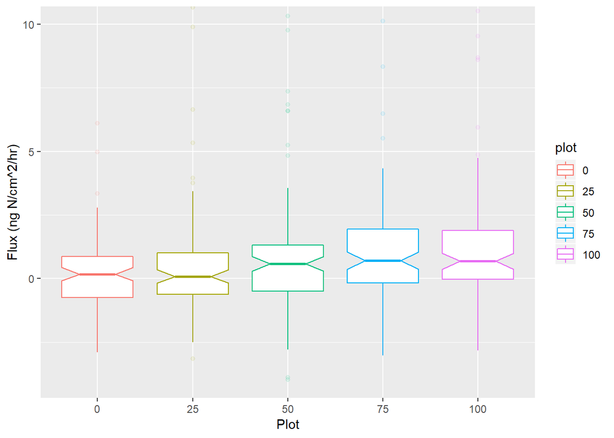

### Kruskal-Wallis non-parametric alternative to one-way Anova with more than two groups

```
## # A tibble: 10 x 8
##    .y.   group1 group2        p  p.adj p.format p.signif method
##    <chr> <chr>  <chr>     <dbl>  <dbl> <chr>    <chr>    <chr>
##  1 flux  0      25     0.793    1      0.79306  ns       Wilcoxon
##  2 flux  0      50     0.0723   0.43   0.07227  ns       Wilcoxon
##  3 flux  0      75     0.00749  0.06   0.00749  **       Wilcoxon
##  4 flux  0      100    0.000428 0.0043 0.00043  ***      Wilcoxon
##  5 flux  25     50     0.169    0.68   0.16943  ns       Wilcoxon
##  6 flux  25     75     0.0136   0.095  0.01360  *        Wilcoxon
##  7 flux  25     100    0.000802 0.0072 0.00080  ***      Wilcoxon
##  8 flux  50     75     0.363    1      0.36261  ns       Wilcoxon
##  9 flux  50     100    0.0867   0.43   0.08671  ns       Wilcoxon
## 10 flux  75     100    0.487    1      0.48717  ns       Wilcoxon
```

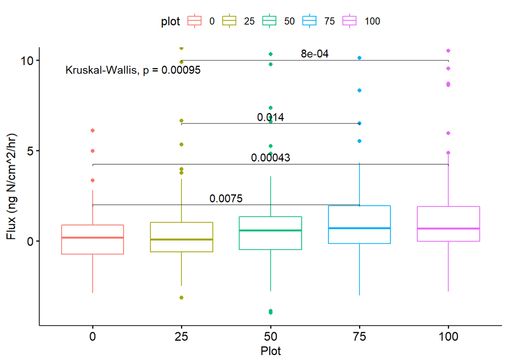

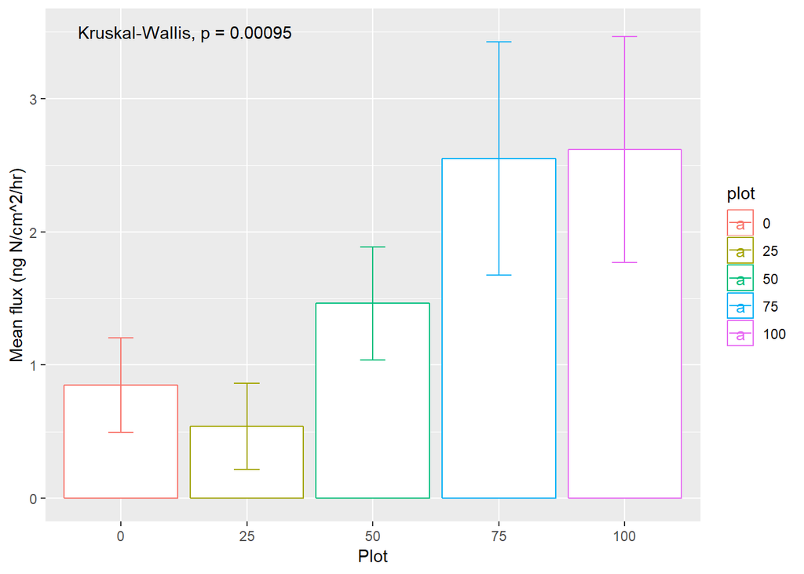

### Field 2

```
##
##  Mood's median test
##
## data:  flux by plot
## X-squared = 24.474, df = 4, p-value = 6.416e-05
```

```
##    0   25   50   75  100
##  "a"  "a"  "b"  "c" "bc"
```

```
## # A tibble: 10 x 8
##    .y.   group1 group2          p    p.adj p.format p.signif method
##    <chr> <chr>  <chr>       <dbl>    <dbl> <chr>    <chr>    <chr>
##  1 flux  0      25     0.767      1        0.76693  ns       Wilcoxon
##  2 flux  0      50     0.00326    0.02     0.00326  **       Wilcoxon
##  3 flux  0      75     0.00000587 0.000059 5.9e-06  ****     Wilcoxon
##  4 flux  0      100    0.0000672  0.00061  6.7e-05  ****     Wilcoxon
##  5 flux  25     50     0.0129     0.064    0.01287  *        Wilcoxon
##  6 flux  25     75     0.000108   0.00086  0.00011  ***      Wilcoxon
##  7 flux  25     100    0.000410   0.00290  0.00041  ***      Wilcoxon
##  8 flux  50     75     0.0788     0.32     0.07885  ns       Wilcoxon
##  9 flux  50     100    0.212      0.64     0.21175  ns       Wilcoxon
## 10 flux  75     100    0.650      1        0.64959  ns       Wilcoxon
```

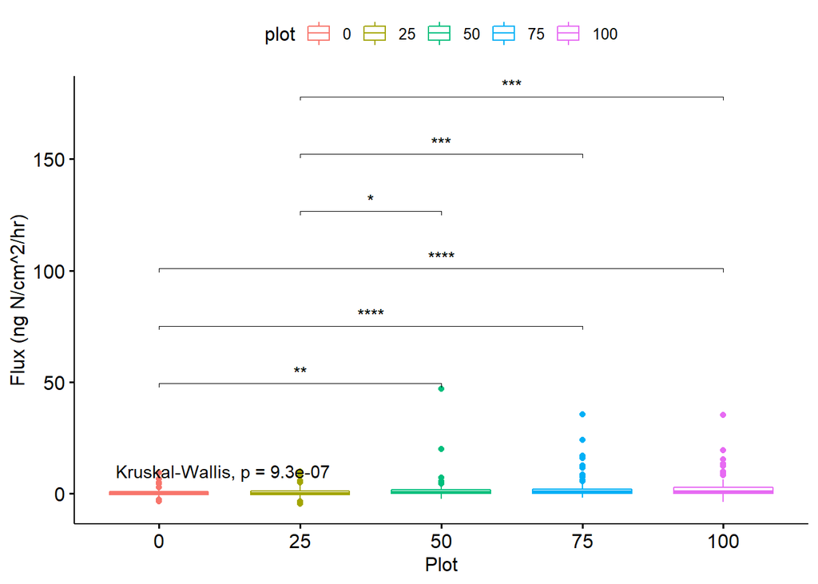

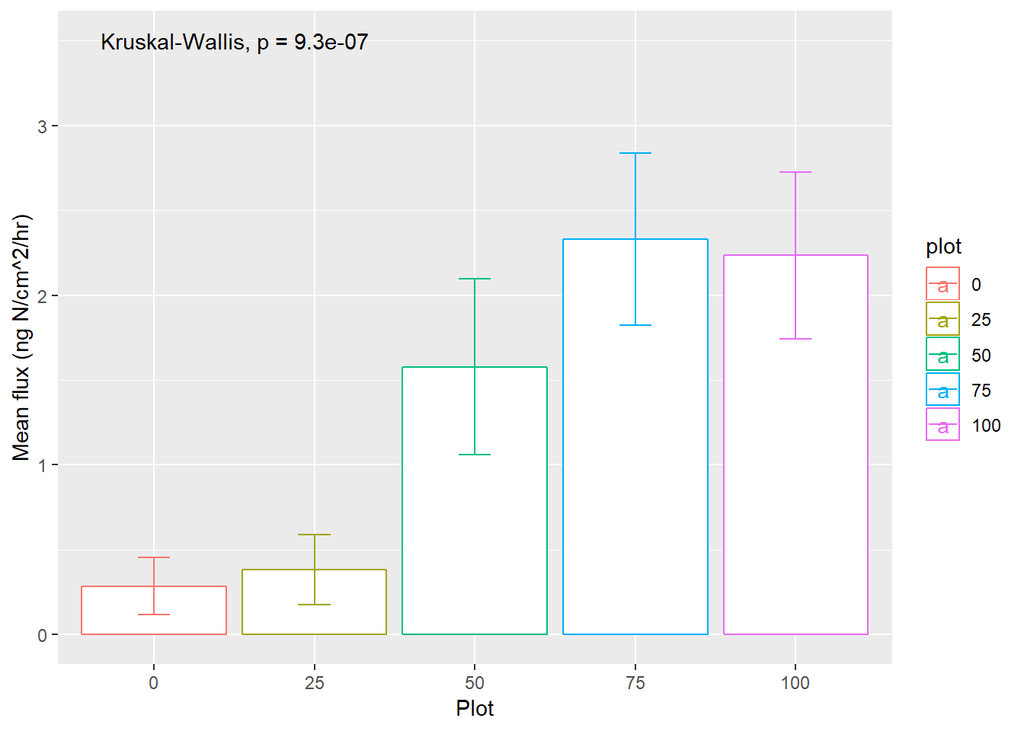

### Field 3

```
##
##  Mood's median test
##
## data:  flux by plot
## X-squared = 40.884, df = 4, p-value = 2.841e-08
```

```
##   0  25  50  75 100
## "a" "a" "a" "b" "b"
```

```
## # A tibble: 10 x 8
##    .y.   group1 group2             p       p.adj p.format p.signif method
##    <chr> <chr>  <chr>          <dbl>       <dbl> <chr>    <chr>    <chr>
##  1 flux  0      25     0.0660        0.2         0.066    ns       Wilcoxon
##  2 flux  0      50     0.0168        0.067       0.017    *        Wilcoxon
##  3 flux  0      75     0.00000000116 0.000000012 1.2e-09  ****     Wilcoxon
##  4 flux  0      100    0.00000000120 0.000000012 1.2e-09  ****     Wilcoxon
##  5 flux  25     50     0.546         1           0.546    ns       Wilcoxon
##  6 flux  25     75     0.00000967    0.000058    9.7e-06  ****     Wilcoxon
##  7 flux  25     100    0.00000285    0.000023    2.9e-06  ****     Wilcoxon
##  8 flux  50     75     0.0000281     0.000140    2.8e-05  ****     Wilcoxon
##  9 flux  50     100    0.00000667    0.000047    6.7e-06  ****     Wilcoxon
## 10 flux  75     100    0.530         1           0.530    ns       Wilcoxon
```

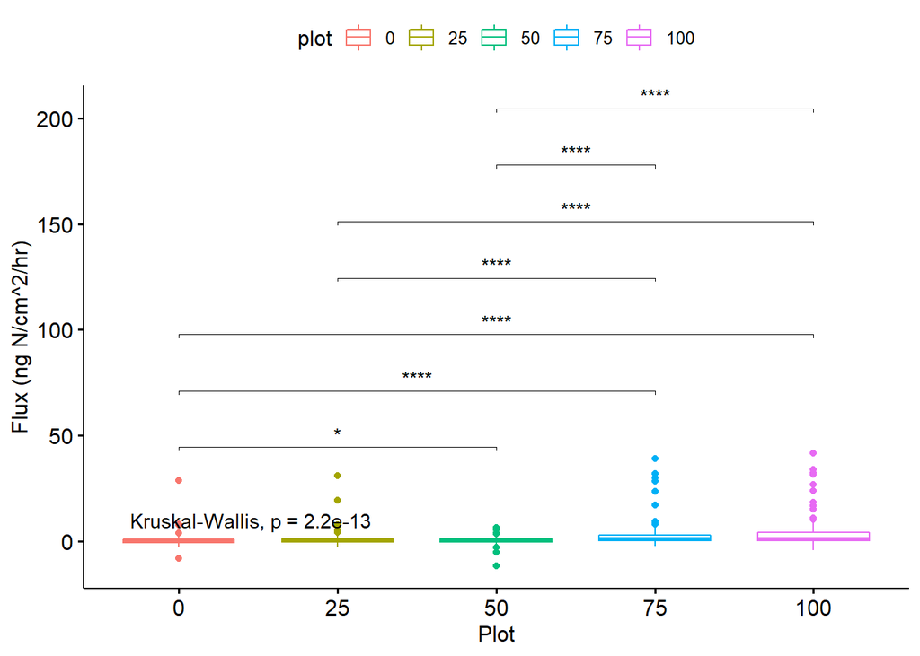

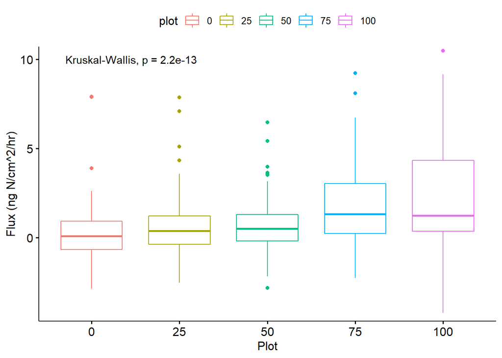

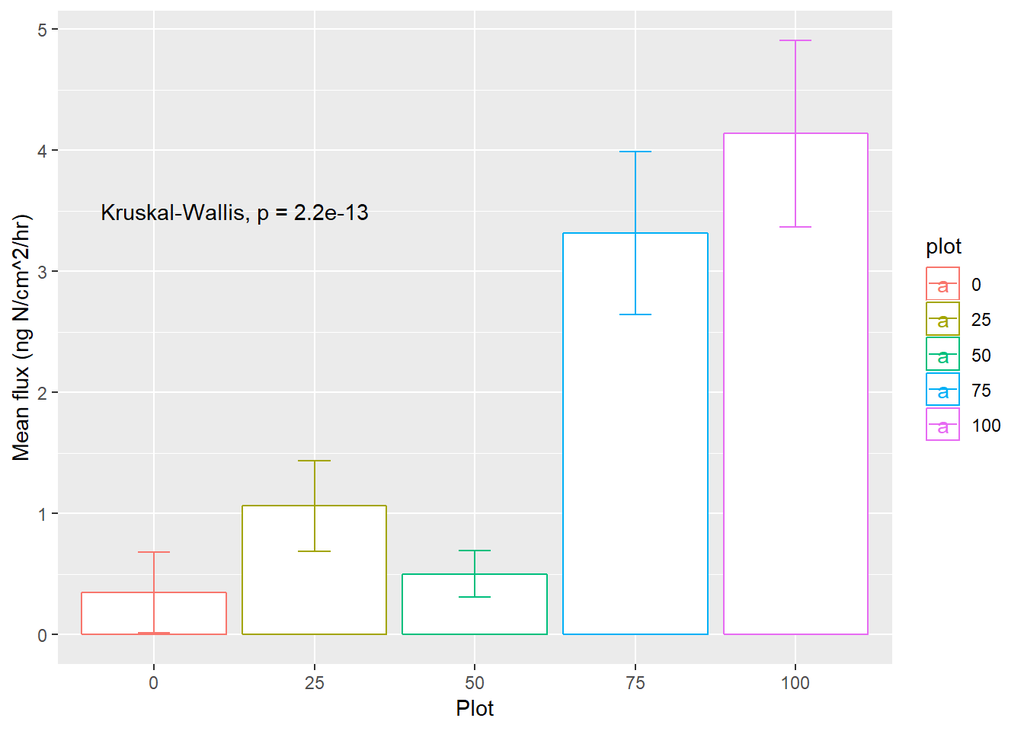

### Field 4

```
##
##  Mood's median test
##
## data:  flux by plot
## X-squared = 67.156, df = 4, p-value = 9.036e-14
```

```
##   0  25  50  75 100
## "a" "a" "a" "b" "b"
```

```
## # A tibble: 10 x 8
##    .y.   group1 group2        p    p.adj p.format p.signif method
##    <chr> <chr>  <chr>     <dbl>    <dbl> <chr>    <chr>    <chr>
##  1 flux  0      25     5.44e- 2 1.60e- 1 0.054    ns       Wilcoxon
##  2 flux  0      50     2.38e- 2 9.50e- 2 0.024    *        Wilcoxon
##  3 flux  0      75     1.19e-13 1.10e-12 1.2e-13  ****     Wilcoxon
##  4 flux  0      100    4.74e-15 4.70e-14 4.7e-15  ****     Wilcoxon
##  5 flux  25     50     7.10e- 1 7.10e- 1 0.710    ns       Wilcoxon
##  6 flux  25     75     6.09e-10 3.70e- 9 6.1e-10  ****     Wilcoxon
##  7 flux  25     100    1.32e-11 1.10e-10 1.3e-11  ****     Wilcoxon
##  8 flux  50     75     4.57e- 9 2.30e- 8 4.6e-09  ****     Wilcoxon
##  9 flux  50     100    1.07e-10 7.50e-10 1.1e-10  ****     Wilcoxon
## 10 flux  75     100    2.63e- 1 5.30e- 1 0.263    ns       Wilcoxon
```

[figure not shown]

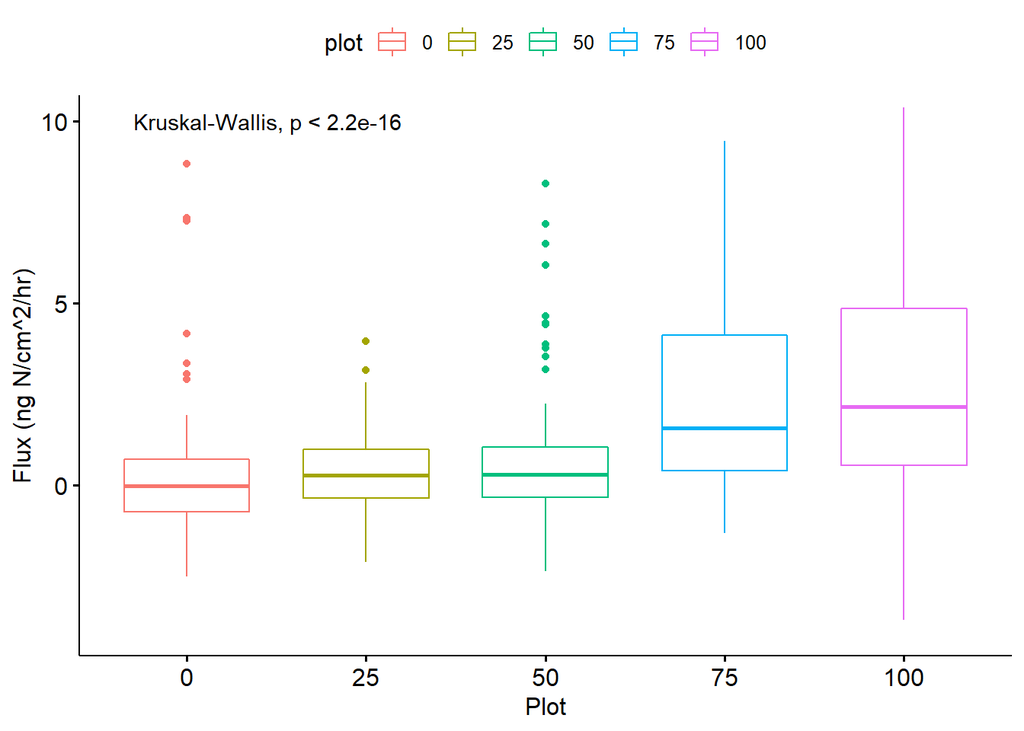

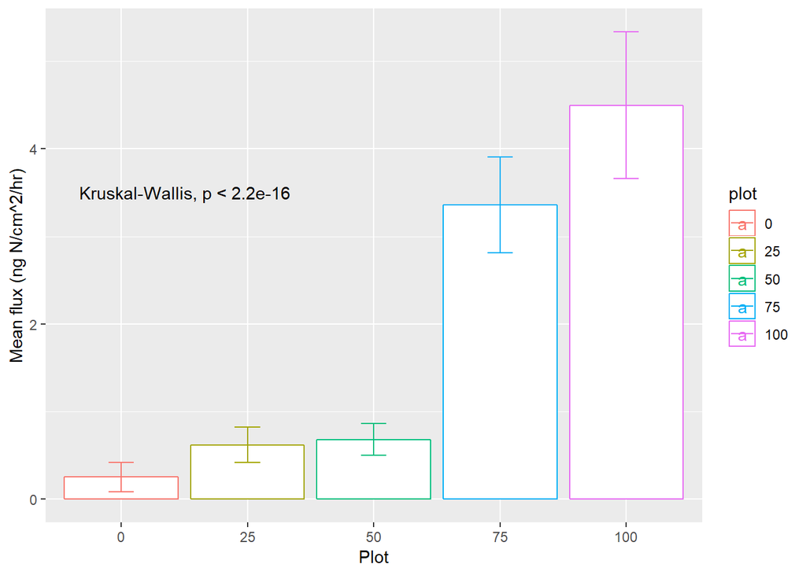